# Lab 04 - Data Visualization

Robin Du

# Learning Goals

- Read in and prepare the meteorological dataset
- Create several graphs with different `geoms()` in `ggplot2`
- Create a facet graph
- Conduct some customizations to the graphs
- Create a more detailed map using `leaflet()`

# Lab Description

We will again work with the meteorological data presented in lecture.

**The objective of the lab is to examine the association between monthly average dew point temperature and relative humidity in four regions of the US and by elevation.**

# Steps

### 1. Read in the data

First download and then read in with data.table:fread()

```r
met <- data.table::fread("C:/PM566/Lab4/met_all.gz")
```

### 2. Prepare the data

- Remove temperatures less than -17C
- Make sure there are no missing data in the key variables coded as 9999, 999, etc
- Take monthly averages by weather station
- Create a region variable for NW, SW, NE, SE based on lon = -98.00 and lat = 39.71 degrees
- Create a categorical variable for elevation as in the lecture slides

```r
met<-met[met$temp > -17]

met[met$elev==9999.0] <- NA

met_avg<-met[,.(temp=mean(temp,na.rm=TRUE), rh=mean(rh,na.rm=TRUE), wind.sp=mean(wind.sp,na.rm=TRUE),
                vis.dist=mean(vis.dist,na.rm=TRUE), dew.point=mean(dew.point,na.rm=TRUE), lat=mean(lat),
                lon=mean(lon), elev=mean(elev,na.rm=TRUE)), by="USAFID"]

met_avg$region <- ifelse(met_avg$lon > -98 & met_avg$lat >39.71, "north east",
                         ifelse(met_avg$lon > -98 & met_avg$lat < 39.71, "south east",
                                ifelse(met_avg$lon < -98 & met_avg$lat >39.71, "north west", "south west")))
table(met_avg$region)
```

```
##
## north east north west south east south west
##        487        147        656        298
```

```r
met_avg$elev_cat <- ifelse(met_avg$elev> 252, "high", "low")
```

### 3. Use `geom_boxplot` to examine the dew point temperature and relative humidity by region

- Use facets
- Make sure to deal with `NA` category
- Describe what you observe in the graph

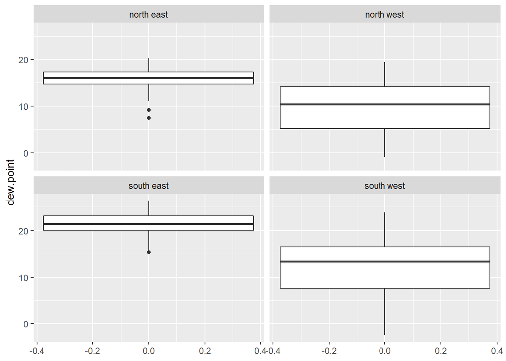

```r
met_avg %>%
  filter(!(region %in% NA)) %>%
ggplot() +
  geom_boxplot(mapping=aes(y=dew.point)) +
  facet_wrap(~region, nrow=2)
```

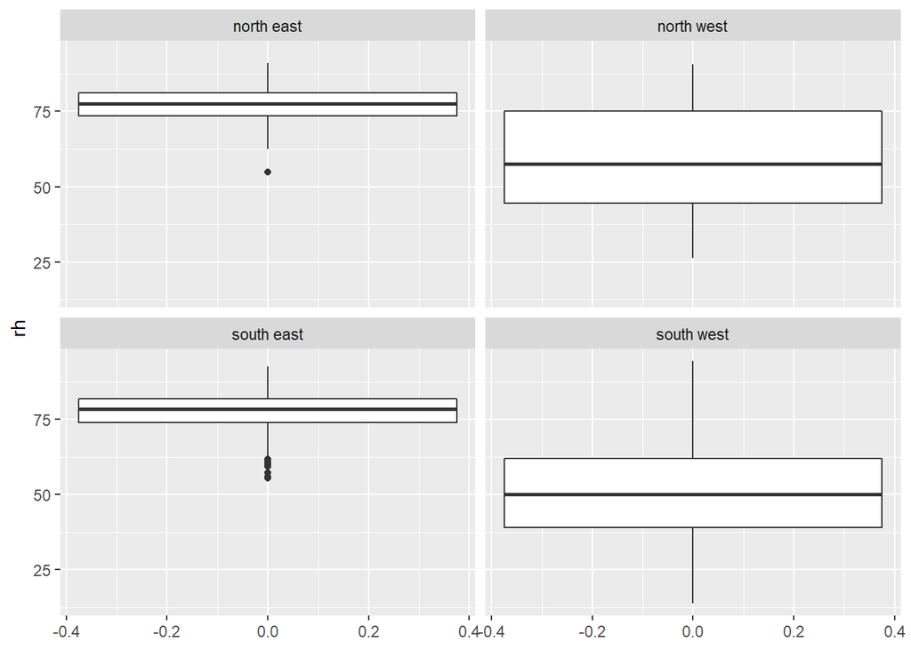

```r
met_avg %>%
  filter(!(region %in% NA)) %>%
ggplot() +
  geom_boxplot(mapping=aes(y=rh)) +
  facet_wrap(~region, nrow=2)
```

- Dew point temperature is higher and less variable in the east than in the west
- Relative humidity is also higher and less variable in the east than in the west

### 4. Use `geom_point` with `stat_smooth` to examine the association between dew point temperature and relative humidity by region

- Colour points by region
- Make sure to deal with `NA` category
- Fit a linear regression line by region
- Describe what you observe in the graph

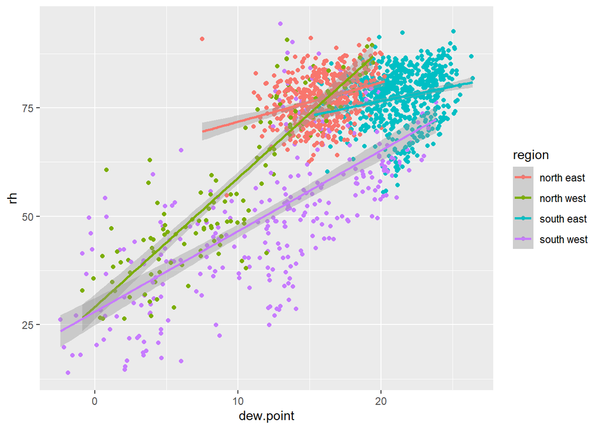

```r
met_avg %>%
  filter(!(region %in% NA)) %>%
ggplot(mapping=aes(x=dew.point, y=rh, color=region)) +
  geom_point() +
  stat_smooth(method=lm)
```

- There is a positive association between dew point temperature and relative humidity for all regions (i.e. an increase in dew point temperature is associated with an increase in relative humidity)
- The association appears to be most positive for the north west region (greatest magnitude for slope)

### 5. Use `geom_bar` to create barplots of the weather stations by elevation category coloured by region

- Make sure to deal with `NA`
- Bars by elevation category
- Change colours from the default. Colour by region using `scale_fill_brewer` see [this](http://rstudio-pubs-static.s3.amazonaws.com/5312_98fc1aba2d5740dd849a5ab797cc2c8d.html)
- Create nice labels on axes and add a title
- Describe what you observe in the graph

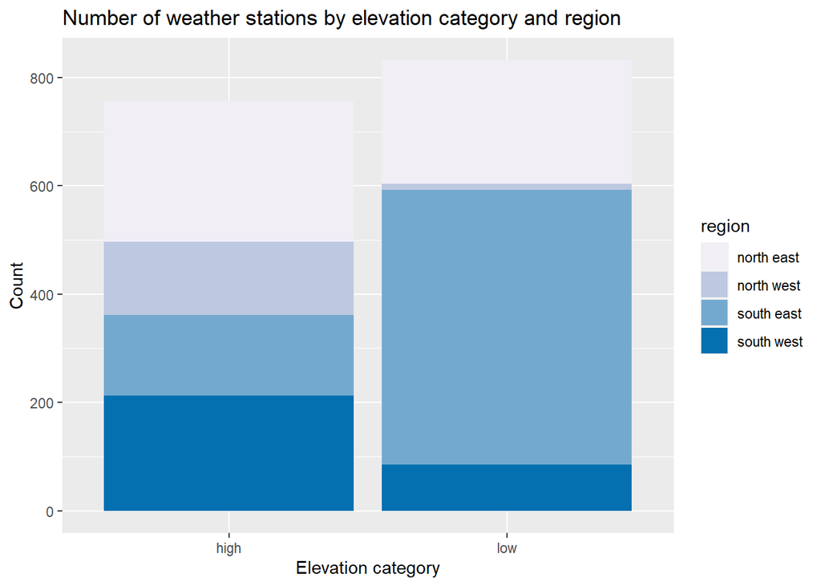

```r
met_avg %>%
  filter(!(region %in% NA)) %>%
ggplot() +
  geom_bar(mapping=aes(x=elev_cat,fill=region)) +
  scale_fill_brewer(palette="PuBu") +
  labs(title="Number of weather stations by elevation category and region",x="Elevation category",y="Count")
```

### 6. Use `stat_summary` to examine mean dew point and relative humidity by region with standard deviation error bars

- Make sure to remove `NA`
- Use fun.data=“mean_sdl” in `stat_summary`
- Describe the graph and what you observe

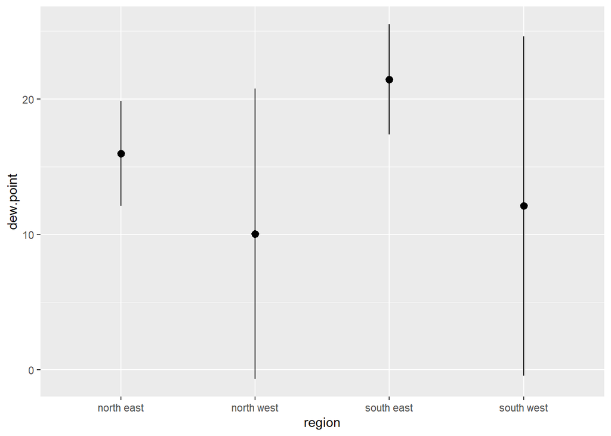

```r
#install.packages("Hmisc")

met_avg %>%
  filter(!(region %in% NA)) %>%
ggplot(mapping=aes(x=region,y=dew.point)) +
  stat_summary(fun.data="mean_sdl")
```

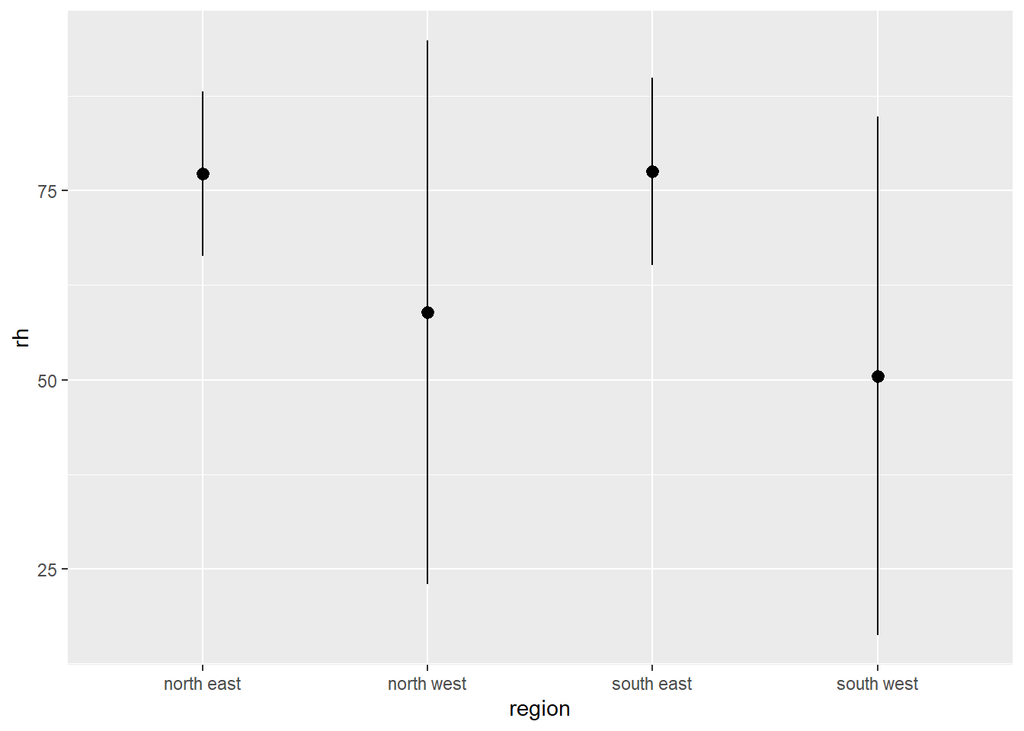

```r
met_avg %>%
  filter(!(region %in% NA)) %>%
ggplot(mapping=aes(x=region,y=rh)) +
  stat_summary(fun.data="mean_sdl")
```

- Dew point temperature is higher on average and less variable in the eastern regions
- Relative humidity is also higher on average and less variable in the eastern regions

### 7. Make a map showing the spatial trend in relative humidity in the US

- Make sure to remove `NA`
- Use leaflet()
- Make a colour palette with custom colours
- Add a legend

```r
met_avg2<-met_avg[!is.na(rh)]
rh_pal = colorNumeric(c('blue','purple','red'), domain=met_avg2$rh)
leaflet(met_avg2) %>%
  addProviderTiles('OpenStreetMap') %>%
  addCircles(lat=~lat, lng=~lon, color=~rh_pal(rh), opacity=1, fillOpacity=1, radius=500) %>%
  addLegend('bottomleft',pal=rh_pal, values=met_avg2$rh, title="Relative Humidity", opacity=1)
```

[interactive chart not shown]

- Relative humidity appears to be highest in the eastern U.S. and along the west coast, lowest in the more inland regions of the western U.S., and moderate in parts of the midwest

### 8. Use a ggplot extension

- Pick an extension (except cowplot) from [here](https://exts.ggplot2.tidyverse.org/gallery/) and make a plot of your choice using the met data (or met_avg)
- Might want to try examples that come with the extension first (e.g. ggtech, gganimate, ggforce)

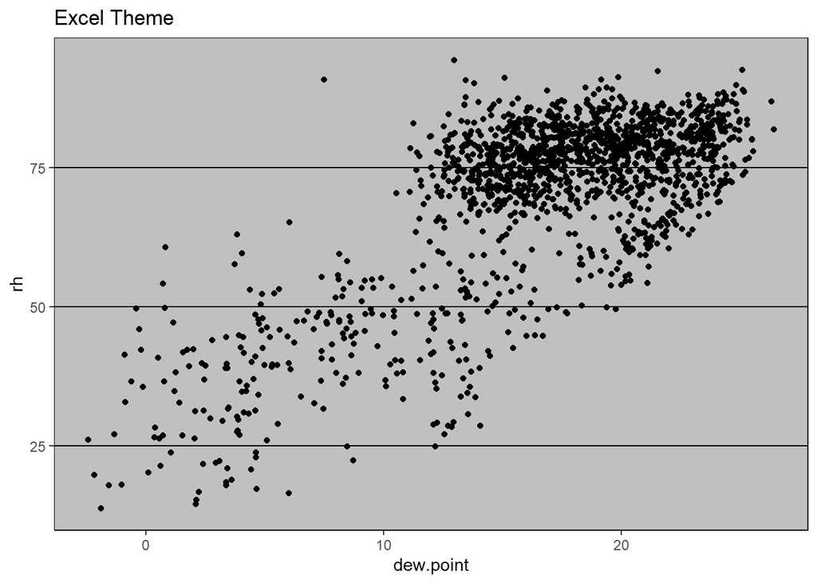

```r
library(ggthemes)
met_avg %>%
  filter(!(region %in% NA)) %>%
ggplot(mapping=aes(x=dew.point, y=rh)) +
  geom_point() +
  theme_excel() +
  labs(title='Excel Theme')
```

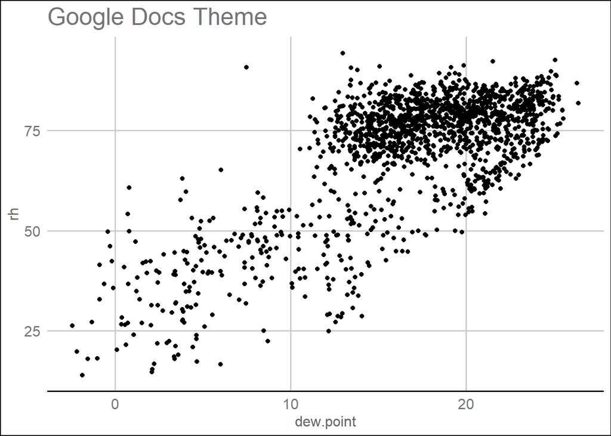

```r
library(ggthemes)
met_avg %>%
  filter(!(region %in% NA)) %>%
ggplot(mapping=aes(x=dew.point, y=rh)) +
  geom_point() +
  theme_gdocs() +
  labs(title='Google Docs Theme')
```